# Final Project Code

## Import Package and Learn about Data

```python
import time

import numpy as np
import pandas as pd
from sklearn.model_selection import train_test_split
from sklearn.model_selection import GridSearchCV

import xgboost as xgb

import matplotlib.pyplot as plt
import seaborn as sns
%matplotlib inline
%config lnlineBackend.figure_format='retina'

pd.set_option('display.width', 1000)
sns.set_style('whitegrid')
```

```python
# load data
train = pd.read_csv('./input/train.csv',dtype={'StateHoliday':object})
store =  pd.read_csv('./input/store.csv') # basic info for each store
test = pd.read_csv('./input/test.csv')
```

```python
# take train data as an example to learn about basic info of data
train.shape
train.info()
train.describe()
train.head()
```

```
(1017209, 9)
```

```
<class 'pandas.core.frame.DataFrame'>
RangeIndex: 1017209 entries, 0 to 1017208
Data columns (total 9 columns):
Store            1017209 non-null int64
DayOfWeek        1017209 non-null int64
Date             1017209 non-null object
Sales            1017209 non-null int64
Customers        1017209 non-null int64
Open             1017209 non-null int64
Promo            1017209 non-null int64
StateHoliday     1017209 non-null object
SchoolHoliday    1017209 non-null int64
dtypes: int64(7), object(2)
memory usage: 69.8+ MB
```

|  | Store | DayOfWeek | Sales | Customers | Open | Promo | SchoolHoliday |
| --- | --- | --- | --- | --- | --- | --- | --- |
| count | 1.017209e+06 | 1.017209e+06 | 1.017209e+06 | 1.017209e+06 | 1.017209e+06 | 1.017209e+06 | 1.017209e+06 |
| mean | 5.584297e+02 | 3.998341e+00 | 5.773819e+03 | 6.331459e+02 | 8.301067e-01 | 3.815145e-01 | 1.786467e-01 |
| std | 3.219087e+02 | 1.997391e+00 | 3.849926e+03 | 4.644117e+02 | 3.755392e-01 | 4.857586e-01 | 3.830564e-01 |
| min | 1.000000e+00 | 1.000000e+00 | 0.000000e+00 | 0.000000e+00 | 0.000000e+00 | 0.000000e+00 | 0.000000e+00 |
| 25% | 2.800000e+02 | 2.000000e+00 | 3.727000e+03 | 4.050000e+02 | 1.000000e+00 | 0.000000e+00 | 0.000000e+00 |
| 50% | 5.580000e+02 | 4.000000e+00 | 5.744000e+03 | 6.090000e+02 | 1.000000e+00 | 0.000000e+00 | 0.000000e+00 |
| 75% | 8.380000e+02 | 6.000000e+00 | 7.856000e+03 | 8.370000e+02 | 1.000000e+00 | 1.000000e+00 | 0.000000e+00 |
| max | 1.115000e+03 | 7.000000e+00 | 4.155100e+04 | 7.388000e+03 | 1.000000e+00 | 1.000000e+00 | 1.000000e+00 |

|  | Store | DayOfWeek | Date | Sales | Customers | Open | Promo | StateHoliday | SchoolHoliday |
| --- | --- | --- | --- | --- | --- | --- | --- | --- | --- |
| 0 | 1 | 5 | 2015-07-31 | 5263 | 555 | 1 | 1 | 0 | 1 |
| 1 | 2 | 5 | 2015-07-31 | 6064 | 625 | 1 | 1 | 0 | 1 |
| 2 | 3 | 5 | 2015-07-31 | 8314 | 821 | 1 | 1 | 0 | 1 |
| 3 | 4 | 5 | 2015-07-31 | 13995 | 1498 | 1 | 1 | 0 | 1 |
| 4 | 5 | 5 | 2015-07-31 | 4822 | 559 | 1 | 1 | 0 | 1 |

```python
store.head()
```

|  | Store | StoreType | Assortment | CompetitionDistance | CompetitionOpenSinceMonth | CompetitionOpenSinceYear | Promo2 | Promo2SinceWeek | Promo2SinceYear | PromoInterval |
| --- | --- | --- | --- | --- | --- | --- | --- | --- | --- | --- |
| 0 | 1 | c | a | 1270.0 | 9.0 | 2008.0 | 0 | NaN | NaN | NaN |
| 1 | 2 | a | a | 570.0 | 11.0 | 2007.0 | 1 | 13.0 | 2010.0 | Jan,Apr,Jul,Oct |
| 2 | 3 | a | a | 14130.0 | 12.0 | 2006.0 | 1 | 14.0 | 2011.0 | Jan,Apr,Jul,Oct |
| 3 | 4 | c | c | 620.0 | 9.0 | 2009.0 | 0 | NaN | NaN | NaN |
| 4 | 5 | a | a | 29910.0 | 4.0 | 2015.0 | 0 | NaN | NaN | NaN |

```python
store.columns
```

```
Index(['Store', 'StoreType', 'Assortment', 'CompetitionDistance', 'CompetitionOpenSinceMonth', 'CompetitionOpenSinceYear', 'Promo2', 'Promo2SinceWeek', 'Promo2SinceYear', 'PromoInterval'], dtype='object')
```

```python
train.columns
```

```
Index(['Store', 'DayOfWeek', 'Date', 'Sales', 'Customers', 'Open', 'Promo', 'StateHoliday', 'SchoolHoliday'], dtype='object')
```

```python
train.shape
test.shape
store.shape
```

```
(1017209, 9)
```

```
(41088, 8)
```

```
(1115, 10)
```

```python
# count the number of null for each attribute
print('train null number: \n',train.isnull().sum())
print('test null number: \n',test.isnull().sum())
print('store null number：\n', store.isnull().sum())
```

```
train null number:
 Store            0
DayOfWeek        0
Date             0
Sales            0
Customers        0
Open             0
Promo            0
StateHoliday     0
SchoolHoliday    0
dtype: int64
test null number:
 Id                0
Store             0
DayOfWeek         0
Date              0
Open             11
Promo             0
StateHoliday      0
SchoolHoliday     0
dtype: int64
store null number：
 Store                          0
StoreType                      0
Assortment                     0
CompetitionDistance            3
CompetitionOpenSinceMonth    354
CompetitionOpenSinceYear     354
Promo2                         0
Promo2SinceWeek              544
Promo2SinceYear              544
PromoInterval                544
dtype: int64
```

## Exploratory Data Analysis(EDA)

```python
# combine train and test data with basic store info
train=pd.merge(train,store,how='left', on='Store')
test=pd.merge(test,store,how='left', on='Store')
```

**From the feature list, the relationships between Sales(label) and features will be visualized. The features contain DayOfWeek, Promo, StateHoliday, SchoolHoliday, StoreType, Assortment, CompetitionDistance, CompetitionOpenSinceMonth, CompetitionOpenSinceYear**

```python
# all of features train data has
train.columns.tolist()
```

### Basic Info for Data

Store number

```python
len(train.Store.value_counts()) # 1115 stores will be involved in the data
train.Store.values.min() #  min store number
train.Store.values.max() # max store number
```

```
1115
```

```
1
```

```
1115
```

Date Info

```python
len(train.Date.value_counts()) # 942 days store sales for train data and 48 days for test data
(train.Date.min())#time start for train data
(train.Date.max())#time end for train data
(test.Date.min())#time start for test data
(test.Date.max())# time end for test data
```

```
942
```

```
'2013-01-01'
```

```
'2015-07-31'
```

```
'2015-08-01'
```

```
'2015-09-17'
```

### DayOfWeek and Sales

```
Text(0.5,1,'Mean Sales of Dayofweek')
```

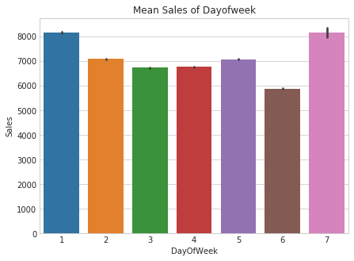

```python
fig, ax = plt.subplots(1, 1, figsize=(7,5))
sns.barplot(x='DayOfWeek', y='Sales', data=train.query('Open==1'), ax=ax).set_title("Mean Sales of Dayofweek")
```

```
Text(0.5,1,'Mean of Sales on DayOfWeek')
```

```
Text(0.5,1,'Mean of Customers on DayOfWeek')
```

```
Text(0.5,1,'Mean of SalesPerCustomer on DayOfWeek')
```

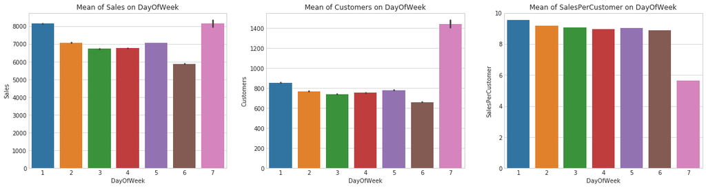

```python
# mean of Sales,Customers,SalesPerCustomer on DayOfWeek(Only the open==1 is calculated)
fig,(axis1,axis2, axis3)=plt.subplots(1,3,figsize=(21,5))
sns.barplot(x='DayOfWeek',y='Sales',data=train.loc[train.Open==1],order=[1,2,3,4,5,6,7],ax=axis1).set_title("Mean of Sales on DayOfWeek")
sns.barplot(x='DayOfWeek',y='Customers',data=train.loc[train.Open==1],order=[1,2,3,4,5,6,7],ax=axis2).set_title("Mean of Customers on DayOfWeek")

#calc the SalesPerCustomer
temp=(train.loc[train.Open==1])[['Sales','Customers','DayOfWeek']].groupby('DayOfWeek').sum()
temp['SalesPerCustomer']=temp['Sales']/temp['Customers']
sns.barplot(x=temp.index,y='SalesPerCustomer',data=temp,order=[1,2,3,4,5,6,7],ax=axis3).set_title("Mean of SalesPerCustomer on DayOfWeek")

# temp=(train.loc[train.Open==1])[['Sales','Customers','StoreType']].groupby('StoreType').sum()
# temp['SalesPerCustomer']=temp['Sales']/temp['Customers']
# sns.barplot(x=temp.index,y='SalesPerCustomer',data=temp,order=['a', 'b', 'c', 'd'],ax=ax4).set_title("Mean of SalesPerCustomer on StoreType")
```

### Sales,Customers on Promo

```
Text(0.5,1,'Mean of Sales on Promo')
```

```
Text(0.5,1,'Mean of Customers on Promo')
```

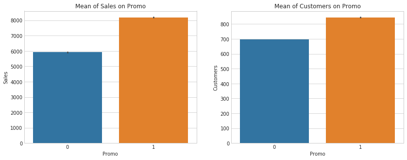

```python
# Sales,Customers on Promo vs Non-Promo
fig,(ax1, ax2)=plt.subplots(1,2,figsize=(14,5))
sns.barplot(x='Promo',y='Sales',data=train[train.Open==1],ax=ax1).set_title("Mean of Sales on Promo")
sns.barplot(x='Promo',y='Customers',data=train[train.Open==1],ax=ax2).set_title("Mean of Customers on Promo")
```

### Count of StateHoliday & Average Sales/Customers of StateHoliday

```
Text(0.5,1,'Count of Stateholiday')
```

```
Text(0.5,1,'Mean Sales of Stateholiday')
```

```
Text(0.5,1,'Mean Customers of Stateholiday')
```

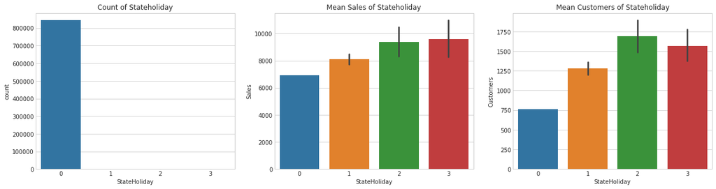

```python
fig, (ax1, ax2, ax3 )= plt.subplots(1,3, figsize=(21, 5))
sns.countplot(x='StateHoliday', data=train, ax=ax1).set_title('Count of Stateholiday')
sns.barplot(x='StateHoliday', y='Sales', data=train[train.Open==1], ax=ax2).set_title('Mean Sales of Stateholiday')
sns.barplot(x='StateHoliday', y='Customers', data=train[train.Open==1], ax=ax3).set_title('Mean Customers of Stateholiday')
```

### Count of SchoolHoliday & Average Sales/Customers of SchoolHoliday

```
Text(0.5,1,'Count of Schoolholiday')
```

```
Text(0.5,1,'Mean Sales of Schoolholiday')
```

```
Text(0.5,1,'Mean Customers of Schoolholiday')
```

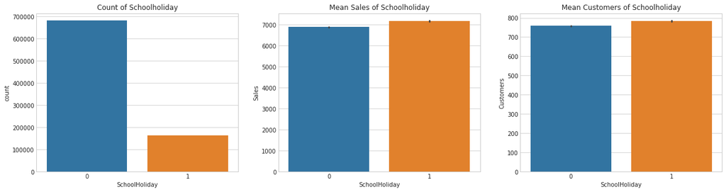

```python
fig, (ax1, ax2, ax3 )= plt.subplots(1,3, figsize=(21, 5))
sns.countplot(x='SchoolHoliday', data=train, ax=ax1).set_title('Count of Schoolholiday')
sns.barplot(x='SchoolHoliday', y='Sales', data=train[train.Open==1], ax=ax2).set_title('Mean Sales of Schoolholiday')
sns.barplot(x='SchoolHoliday', y='Customers', data=train[train.Open==1], ax=ax3).set_title('Mean Customers of Schoolholiday')
```

### Sales/Customers distribution

```python
train['Saleslog']=np.log1p(train.Sales)
```

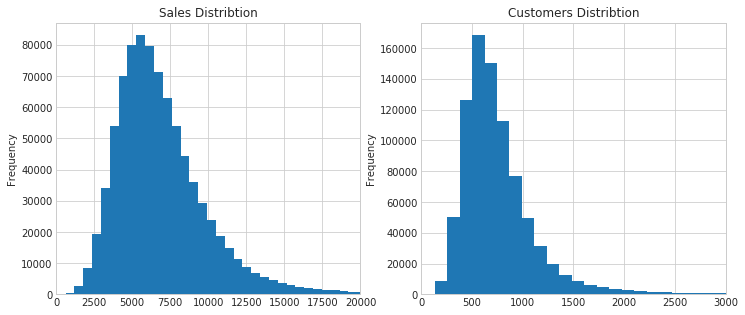

```python
fig,( ax1, ax2)= plt.subplots(1,2, figsize=(12,5))
_ = train.Sales.plot(kind='hist', bins=60,xlim=(0, 20000), title='Sales Distribtion',ax=ax1)
_ = train.Customers.plot(kind='hist', bins=60, xlim=(0, 3000), title='Customers Distribtion', ax=ax2)
```

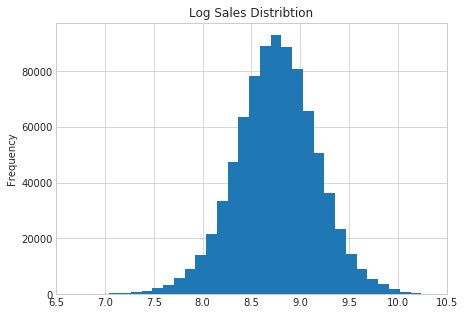

```python
fig,( ax1 )= plt.subplots(1, figsize=(7,5))
_ = train.Saleslog[train.Saleslog>0].plot(kind='hist', bins=60,xlim=(6.5, 10.5), title='Log Sales Distribtion',ax=ax1)
```

### Sales Changing with Time

```python
train.Date=pd.to_datetime(train.Date)
train['Month']=train.Date.dt.month
train['Year'] = train.Date.dt.year
```

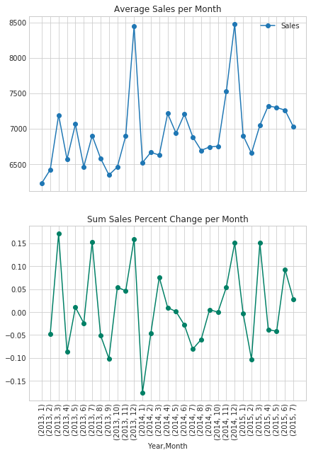

```python
fig, (ax1, ax2)= plt.subplots(2, 1, figsize=(7,10), sharex=True)
average_sales = train.query('Open==1').groupby(['Year','Month'])['Sales'].mean()
pct_change_sales = train.query('Open==1').groupby(['Year','Month'])['Sales'].sum().pct_change()

_ = average_sales.plot(legend=True, ax=ax1,  marker='o', title='Average Sales per Month')
_ = _.set_xticks(range(len(average_sales)))
_ =pct_change_sales.plot(ax=ax2, marker='o',rot=90,colormap='summer',title='Sum Sales Percent Change per Month')
```

### StoreType: count & average sales/customers

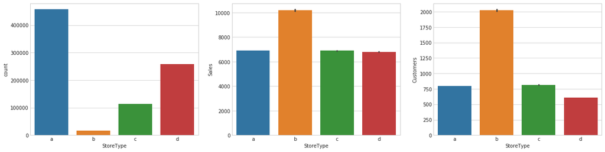

```python
fig, (ax1, ax2, ax3)=plt.subplots(1,3, figsize=(21,5))
_ = sns.countplot(x='StoreType', data=train, order=['a','b','c','d'],ax=ax1)
_ = sns.barplot(x='StoreType', y='Sales', data=train[train['Open']==1], order=['a','b','c','d'], ax=ax2)
_ = sns.barplot(x='StoreType', y='Customers', data=train[train['Open']==1], order=['a','b','c','d'], ax=ax3)
```

### Assortment: count & average sales/customers

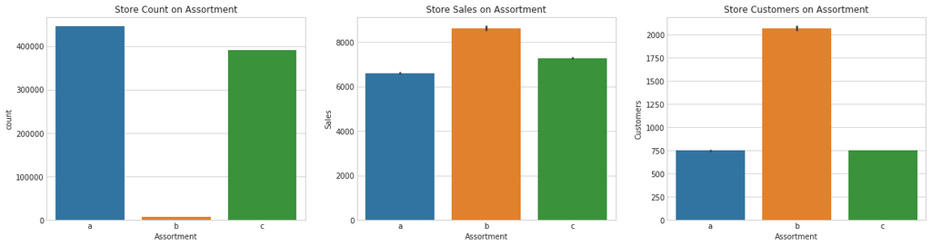

```python
fig, (ax1, ax2, ax3) = plt.subplots(1, 3, figsize=(21,5))
_ = sns.countplot(x='Assortment', data=train.query('Open==1'), order=['a', 'b', 'c'], ax=ax1).set_title('Store Count on Assortment')
_ = sns.barplot(x='Assortment', y='Sales', data=train.query('Open==1'), order=['a', 'b', 'c'], ax=ax2).set_title('Store Sales on Assortment')
_ = sns.barplot(x='Assortment', y='Customers', data=train.query('Open==1'), order=['a', 'b', 'c'], ax=ax3).set_title('Store Customers on Assortment')
```

### Competition Distance

```python
tmp = train.loc[train.Open==1, ['Sales', 'Store', 'CompetitionDistance']].groupby('Store').mean()
```

```
Text(0.5,1,'Scatter of Sales and CompetitionDistance')
```

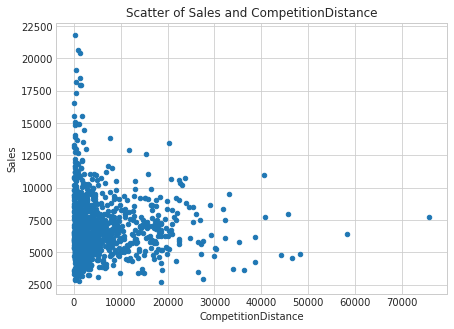

```python
tmp.plot(kind='scatter', x='CompetitionDistance', y='Sales', figsize=(7,5)).set_title('Scatter of Sales and CompetitionDistance')
```

### the Competition's effect on Sales

```python
# select samples having a competition
tmp = train.loc[(train.CompetitionOpenSinceMonth>=train.Month)&(train.CompetitionOpenSinceYear>=train.Year),:]
```

```python
# random choose a store and look at the differenct sales before and after competition
store_num = np.random.choice(tmp.Store.unique().tolist(),1)
```

```python
store_data_mean = train.loc[(train.Store==int(store_num))&(train.Open==1),:].groupby(['Year', 'Month']).mean()['Sales']
store_data_sum = train.loc[(train.Store==int(store_num))&(train.Open==1),:].groupby(['Year', 'Month']).sum()['Sales']
```

```python
y = int(train.loc[(train.Store==int(store_num))&(train.Open==1),:].groupby(['Year', 'Month']).mean().CompetitionOpenSinceYear.unique())
m = int(train.loc[(train.Store==int(store_num))&(train.Open==1),:].groupby(['Year', 'Month']).mean().CompetitionOpenSinceMonth.unique())
print(y,m)
```

```
2013 9
```

```python
store_data  = train.loc[(train.Store==int(store_num))&(train.Open==1)]
```

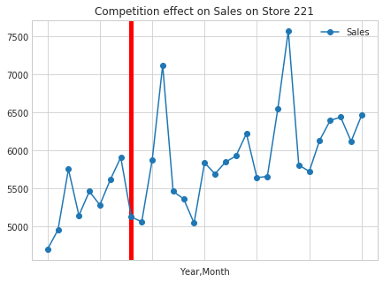

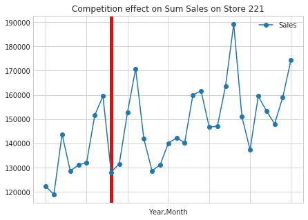

```python
# fig, (ax1, ax2)=plt.subplots(2,1, figsize=(15,8), sharex=True)
_ = plt.axvline(x=(y-2013)*12+(m-1),linewidth=5,color='red')

_ = store_data_mean.plot(marker='o', figsize=(7,5), legend=True, rot=90,
                                       title='Competition effect on Sales on Store {}'.format(int(store_num)))
x = ax.set_xticks((range(len(store_data.index.tolist()))))
_ = plt.show()
_ = plt.axvline(x=(y-2013)*12+(m-1),linewidth=5,color='red')

_ = store_data_sum.plot(marker='o', figsize=(7,5), legend=True, rot=90,
                                       title='Competition effect on Sum Sales on Store {}'.format(int(store_num)))
# _ = plt.show()
```

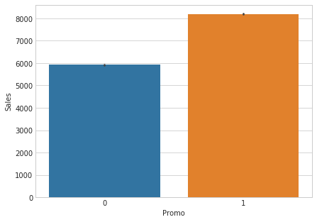

```python
fig, ax = plt.subplots(figsize=(7, 5))
sns.barplot(x='Promo', y='Sales', data=train.query("Open==1"))
```

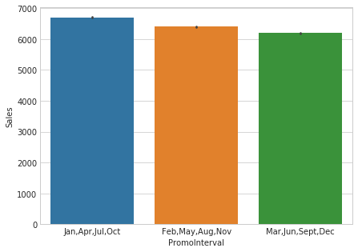

```python
fig, ax = plt.subplots(figsize=(7, 5))
sns.barplot(x='PromoInterval', y='Sales', data=train.query("Open==1"))
```

## Data Preprocessing

```python
#reread data
train = pd.read_csv('./input/train.csv',dtype={'StateHoliday':object})
store =  pd.read_csv('./input/store.csv')
test = pd.read_csv('./input/test.csv')
```

```python
# count null features
train.isnull().sum()
store.isnull().sum()
test.isnull().sum()
```

```
Store            0
DayOfWeek        0
Date             0
Sales            0
Customers        0
Open             0
Promo            0
StateHoliday     0
SchoolHoliday    0
dtype: int64
```

```
Store                          0
StoreType                      0
Assortment                     0
CompetitionDistance            3
CompetitionOpenSinceMonth    354
CompetitionOpenSinceYear     354
Promo2                         0
Promo2SinceWeek              544
Promo2SinceYear              544
PromoInterval                544
dtype: int64
```

```
Id                0
Store             0
DayOfWeek         0
Date              0
Open             11
Promo             0
StateHoliday      0
SchoolHoliday     0
dtype: int64
```

```python
# Only missing data for test data is the store number 622.
# Data of store num 622 should be 0 based on the page description
# page: https://www.kaggle.com/c/rossmann-store-sales/discussion/17048#96969
test[test.Open.isnull()]
test.fillna(0, inplace=True)
```

|  | Id | Store | DayOfWeek | Date | Open | Promo | StateHoliday | SchoolHoliday |
| --- | --- | --- | --- | --- | --- | --- | --- | --- |
| 479 | 480 | 622 | 4 | 2015-09-17 | NaN | 1 | 0 | 0 |
| 1335 | 1336 | 622 | 3 | 2015-09-16 | NaN | 1 | 0 | 0 |
| 2191 | 2192 | 622 | 2 | 2015-09-15 | NaN | 1 | 0 | 0 |
| 3047 | 3048 | 622 | 1 | 2015-09-14 | NaN | 1 | 0 | 0 |
| 4759 | 4760 | 622 | 6 | 2015-09-12 | NaN | 0 | 0 | 0 |
| 5615 | 5616 | 622 | 5 | 2015-09-11 | NaN | 0 | 0 | 0 |
| 6471 | 6472 | 622 | 4 | 2015-09-10 | NaN | 0 | 0 | 0 |
| 7327 | 7328 | 622 | 3 | 2015-09-09 | NaN | 0 | 0 | 0 |
| 8183 | 8184 | 622 | 2 | 2015-09-08 | NaN | 0 | 0 | 0 |
| 9039 | 9040 | 622 | 1 | 2015-09-07 | NaN | 0 | 0 | 0 |
| 10751 | 10752 | 622 | 6 | 2015-09-05 | NaN | 0 | 0 | 0 |

```python
#for all attributes, missing values are about Promo
# it means that no promo and all attributes should be set to 0.
store['Promo2SinceWeek'].fillna(0,inplace=True)
store['Promo2SinceYear'].fillna(0,inplace=True)
store['PromoInterval'].fillna(0,inplace=True)
```

```python
store.isnull().sum()
```

```
Store                          0
StoreType                      0
Assortment                     0
CompetitionDistance            3
CompetitionOpenSinceMonth    354
CompetitionOpenSinceYear     354
Promo2                         0
Promo2SinceWeek                0
Promo2SinceYear                0
PromoInterval                  0
dtype: int64
```

```python
store.fillna(0, inplace=True) # to represent missing value by using 0
```

```python
# only choose data when feature Open is 1 for test data
# for train data, the value of sales over than 0 will be chosen.
test = test[test.Open==1]
train = train[train.Sales>1]
```

## Feature Engineering

```python
# combine train and test data so that they can dealt with together
# create a feature set so that data can be easily split after feature engineering
train['Set']=1
test['Set']=0
data = pd.concat([train, test])
```

```python
train.shape
test.shape
data.shape
train.head(3)
test.head(3)
data.head(3)
```

```
(844338, 10)
```

```
(35093, 9)
```

```
(879431, 11)
```

|  | Store | DayOfWeek | Date | Sales | Customers | Open | Promo | StateHoliday | SchoolHoliday | Set |
| --- | --- | --- | --- | --- | --- | --- | --- | --- | --- | --- |
| 0 | 1 | 5 | 2015-07-31 | 5263 | 555 | 1 | 1 | 0 | 1 | 1 |
| 1 | 2 | 5 | 2015-07-31 | 6064 | 625 | 1 | 1 | 0 | 1 | 1 |
| 2 | 3 | 5 | 2015-07-31 | 8314 | 821 | 1 | 1 | 0 | 1 | 1 |

|  | Id | Store | DayOfWeek | Date | Open | Promo | StateHoliday | SchoolHoliday | Set |
| --- | --- | --- | --- | --- | --- | --- | --- | --- | --- |
| 0 | 1 | 1 | 4 | 2015-09-17 | 1.0 | 1 | 0 | 0 | 0 |
| 1 | 2 | 3 | 4 | 2015-09-17 | 1.0 | 1 | 0 | 0 | 0 |
| 2 | 3 | 7 | 4 | 2015-09-17 | 1.0 | 1 | 0 | 0 | 0 |

|  | Customers | Date | DayOfWeek | Id | Open | Promo | Sales | SchoolHoliday | Set | StateHoliday | Store |
| --- | --- | --- | --- | --- | --- | --- | --- | --- | --- | --- | --- |
| 0 | 555.0 | 2015-07-31 | 5 | NaN | 1.0 | 1 | 5263.0 | 1 | 1 | 0 | 1 |
| 1 | 625.0 | 2015-07-31 | 5 | NaN | 1.0 | 1 | 6064.0 | 1 | 1 | 0 | 2 |
| 2 | 821.0 | 2015-07-31 | 5 | NaN | 1.0 | 1 | 8314.0 | 1 | 1 | 0 | 3 |

```python
train.columns
```

```
Index(['Store', 'DayOfWeek', 'Date', 'Sales', 'Customers', 'Open', 'Promo', 'StateHoliday', 'SchoolHoliday', 'Set'], dtype='object')
```

```python
# Obtain label
# features will be used for modeling
# convert label to log number ???why do we need to transform

features =['Store', 'DayOfWeek', 'Promo']
data['Saleslog']=np.log1p(data.Sales)
label='Saleslog'
```

```python
# create more features by taking advantage of Date feature
data['Date'] = pd.to_datetime(data['Date'])
data['Year'] = data['Date'].dt.year
data['Month'] = data['Date'].dt.month
data['Day'] = data['Date'].dt.day
data['WeekOfYear'] = data['Date'].dt.weekofyear
data['Season'] = data['Date'].dt.quarter
features.extend(['Year', 'Month', 'Day', 'WeekOfYear', 'Season'])
```

```python
# mering store data
data = data.merge(store, how='left', on='Store')
# features.extend(['SalesPerDay', 'CustomersPerDay', 'SalesPerCustomersPerDay'])
```

```python
# https://www.kaggle.com/cast42/xgboost-in-python-with-rmspe-v2/code
# calculate competitionOpen based on competitionOpen time
features.append('CompetitionOpen')
data['CompetitionOpen'] = 12 * (data.Year - data.CompetitionOpenSinceYear) + \
    (data.Month - data.CompetitionOpenSinceMonth)
```

```python
# Promo open time in months
# create feature PromoOpen time
# filter some invalid data

features.append('PromoOpen')
data['PromoOpen'] = 12 * (data.Year - data.Promo2SinceYear) + \
    (data.WeekOfYear - data.Promo2SinceWeek) / 4.0
data['PromoOpen'] = data.PromoOpen.apply(lambda x: x if x > 0 else 0)
data.loc[data.Promo2SinceYear == 0, 'PromoOpen'] = 0
```

```python
# https://www.kaggle.com/cast42/xgboost-in-python-with-rmspe-v2/code
# transfer feature PromoInterval to numbers

features.append('IsPromoMonth')
month2str = {1:'Jan', 2:'Feb', 3:'Mar', 4:'Apr', 5:'May', 6:'Jun', \
         7:'Jul', 8:'Aug', 9:'Sept', 10:'Oct', 11:'Nov', 12:'Dec'}
data['monthStr'] = data.Month.map(month2str)
data.loc[data.PromoInterval == 0, 'PromoInterval'] = ''
data['IsPromoMonth'] = 0
for interval in data.PromoInterval.unique():
    if interval != '':
        for month in interval.split(','):
            data.loc[(data.monthStr == month) & (data.PromoInterval == interval), 'IsPromoMonth'] = 1
```

```python
data.PromoInterval.value_counts()
```

```
                    438095
Jan,Apr,Jul,Oct     254101
Feb,May,Aug,Nov     102851
Mar,Jun,Sept,Dec     84384
Name: PromoInterval, dtype: int64
```

```python
data.dtypes[data.dtypes=='object'] #check object attributes and convert them later
```

```
StateHoliday     object
StoreType        object
Assortment       object
PromoInterval    object
monthStr         object
dtype: object
```

```python
# used for benchmark model
data = pd.concat([data, pd.get_dummies(data['StoreType'],prefix='StoreType',drop_first=True),pd.get_dummies(data['Assortment'],prefix='Assortment',drop_first=True), pd.get_dummies(data['StateHoliday'],prefix='StateHoliday',drop_first=True)],axis=1)
```

```python
data.columns
```

```
Index(['Customers', 'Date', 'DayOfWeek', 'Id', 'Open', 'Promo', 'Sales', 'SchoolHoliday', 'Set', 'StateHoliday', 'Store', 'Saleslog', 'Year', 'Month', 'Day', 'WeekOfYear', 'Season', 'StoreType', 'Assortment', 'CompetitionDistance', 'CompetitionOpenSinceMonth', 'CompetitionOpenSinceYear', 'Promo2', '…
```

```python
features.extend(['StoreType_b', 'StoreType_c', 'StoreType_d', 'Assortment_b', 'Assortment_c', 'StateHoliday_a', 'StateHoliday_b','StateHoliday_c'])
```

```python
# directly used for tree model
# data['PromoInterval'] = data['PromoInterval'].astype('category').cat.codes #不考虑此特征，已经更换为isPromoMonth

data['StoreType'] = data['StoreType'].astype('category').cat.codes
data['Assortment'] = data['Assortment'].astype('category').cat.codes
data['StateHoliday'] = data['StateHoliday'].astype('category').cat.codes
features.extend(['StoreType', 'Assortment', 'CompetitionDistance', 'Promo2'])
```

```python
# transfer data type to save memory
data.IsPromoMonth = data.IsPromoMonth.astype('int16')
data.Year = data.Year.astype('int16')
data.Promo2SinceYear = data.Promo2SinceYear.astype('int16')
data.Promo2SinceWeek = data.Promo2SinceWeek.astype('int16')
data.Promo2 = data.Promo2.astype('int16')
data.CompetitionDistance = data.CompetitionDistance.astype('int16')
data.SchoolHoliday = data.SchoolHoliday.astype('int16')
data.Set = data.Set.astype('int16')
# data.Customers = data.Customers.astype('int16')
# data.Id = data.Id.astype('int16')
# data.Sales = data.Sales.astype('int16')
data.CompetitionOpenSinceMonth = data.CompetitionOpenSinceMonth.astype('int16')
data.CompetitionOpenSinceYear = data.CompetitionOpenSinceYear.astype('int16')
data.CompetitionOpen = data.CompetitionOpen.astype('int16')
data.PromoOpen = data.PromoOpen.astype('int16')
```

```python
features_used_to_benchmark = ['Store','DayOfWeek','Promo','SchoolHoliday','Year','Month','Day','WeekOfYear','Season',
 'CompetitionDistance','Promo2','CompetitionOpen', 'PromoOpen','IsPromoMonth',
'StoreType_b', 'StoreType_c', 'StoreType_d', 'Assortment_b', 'Assortment_c',
                            'StateHoliday_a', 'StateHoliday_b','StateHoliday_c']
label='Saleslog'
```

## modeling

### benchmark1： Linear Regression Without extra features and combo features

#### Linear Regression

```python
from sklearn.linear_model import ElasticNet
from sklearn.model_selection import KFold, cross_val_score, train_test_split
from sklearn.model_selection import GridSearchCV
parameters = {'alpha':[0.005,0.0005,0.05], 'l1_ratio':[0.7, 0.8, 0.9]}
clf = GridSearchCV(ElasticNet(),parameters,cv=10)
```

```python
clf.fit(data.loc[(data['Set']==1)&(data['Open']==1)][features_used_to_benchmark],
   data.loc[(data['Set']==1)&(data['Open']==1)][label])
```

```
GridSearchCV(cv=10, error_score='raise',
       estimator=ElasticNet(alpha=1.0, copy_X=True, fit_intercept=True, l1_ratio=0.5,
      max_iter=1000, normalize=False, positive=False, precompute=False,
      random_state=None, selection='cyclic', tol=0.0001, warm_start=False),
       fit_params=None, iid=True, n_jobs=1,
       param_grid={'alpha': [0.005, 0.0005, 0.05], 'l1_ratio': [0.7, 0.8, 0.9]},
       pre_dispatch='2*n_jobs', refit=True, return_train_score='warn',
       scoring=None, verbose=0)
```

```python
benchmark_result = pd.DataFrame({"Id": test["Id"], 'Sales': np.expm1(clf.predict(data.loc[data['Set']==0][features_used_to_benchmark]))})
a = pd.read_csv('./input/sample_submission.csv')
benchmark_result.Id = benchmark_result.Id.astype('int')
benchmark_result = a.merge(benchmark_result,how='left', on='Id')[['Id','Sales_y']].rename(columns={'Sales_y':'Sales'})
benchmark_result.fillna(0,inplace=True)
benchmark_result.to_csv('benchmark_result.csv',index=False )
```

### Evaluation Function

```python
# evaluation function
def ToWeight(y):
    w = np.zeros(y.shape, dtype=float)
    ind = y != 0
    w[ind] = 1./(y[ind]**2)
    return w

def rmspe(yhat, y):
    w = ToWeight(y)
    rmspe = np.sqrt(np.mean( w * (y - yhat)**2 ))
    return rmspe

def rmspe_xg(yhat, y):
    # y = y.values
    y = y.get_label()
    y = np.exp(y) - 1
    yhat = np.exp(yhat) - 1
    w = ToWeight(y)
    rmspe = np.sqrt(np.mean(w * (y - yhat)**2))
    return "rmspe", rmspe
```

### benchmark2： XGBoost Without extra features and combo features

```python
seed = 42
import time
start=time.time()
X_train, X_test, y_train, y_test = train_test_split(data.loc[(data['Set'] == 1)&(data['Open']==1)][features],
                                                    data.loc[(data['Set'] == 1)&(data['Open']==1)][label], test_size=0.015, random_state=seed)
#     X_train = data.loc[(data.Set==1)&(data.Date<='2015-05')][features]
#     y_train = data.loc[(data.Set==1)&(data.Date<='2015-05')][label]
#     X_test = data.loc[(data.Set==1)&(data.Date>'2015-05')][features]
#     y_test = data.loc[(data.Set==1)&(data.Date>'2015-05')][label]
dtrain = xgb.DMatrix(X_train, y_train)
dtest = xgb.DMatrix(X_test, y_test)
num_round = 20000
evallist = [(dtrain, 'train'), (dtest, 'test')]
param = {"objective": "reg:linear",
          "booster" : "gbtree",
          "eta": 0.01,
          "max_depth": 10,
          "subsample": 0.9,
          "colsample_bytree": 0.7,
          "silent": 1,
          "seed": seed
          }

plst = param.items()
bst1 = xgb.train(plst, dtrain, num_round, evallist, feval=rmspe_xg, verbose_eval=250, early_stopping_rounds=250)
X_submit = data.loc[data['Set'] == 0]
dsubmit = xgb.DMatrix(X_submit[features])
ypred_bst = bst1.predict(dsubmit)

data_ypred = X_submit['Id'].reset_index()
del data_ypred['index']
data_ypred['Id'] = data_ypred['Id'].astype('int')

# data_ypred['Sales'] = (np.exp(ypred_bst) - 1) * 0.985
data_ypred['Sales'] = (np.exp(ypred_bst) - 1)

data_ypred.sort_values('Id', inplace=True)
name =str(seed)+'benchmark'+'basicfeatures.csv'
data_ypred[['Id', 'Sales']].to_csv(name, index=False)
print(time.time()-start)
```

[output not shown]

```python
a = pd.read_csv('./input/sample_submission.csv')
b = pd.read_csv('./42benchmarkbasicfeatures.csv')
```

```python
b.Id = b.Id.astype('int')
b = a.merge(b,how='left', on='Id')[['Id','Sales_y']].rename(columns={'Sales_y':'Sales'})
b.fillna(0,inplace=True)
b.to_csv('Benchmark2_XGBoost.csv',index=False )
```

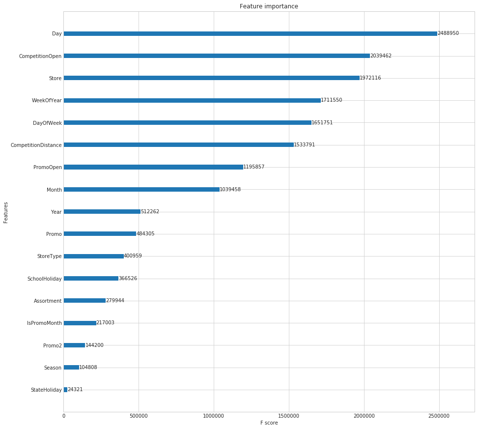

```python
# feature importance plot
fig, ax = plt.subplots(figsize=(15,7))
xgb.plot_importance(bst1,ax=ax, )
```

### Adding extra and combo features

#### Based on explorary data analysis result，related features can be created by combing store, dayofweek, promo, year features

```python
columns = ['Store', 'DayOfWeek', 'Promo', 'Year']
```

```python
train = data[data.Set==1]
test = data[data.Set==0]
```

```python
test = pd.merge(test, train.groupby(columns)['Sales'].mean().reset_index().rename(columns={'Sales':'MeanSales'}), on=columns,how='left')
test = pd.merge(test, train.groupby(columns)['Sales'].median().reset_index().rename(columns={'Sales':'MedianSales'}), on=columns,how='left')
train = pd.merge(train, train.groupby(columns)['Sales'].mean().reset_index().rename(columns={'Sales':'MeanSales'}), on=columns,how='left')
train = pd.merge(train, train.groupby(columns)['Sales'].median().reset_index().rename(columns={'Sales':'MedianSales'}), on=columns,how='left')
features.extend(['MeanSales', 'MedianSales'])
```

```python
train.columns
```

```
Index(['Customers', 'Date', 'DayOfWeek', 'Id', 'Open', 'Promo', 'Sales', 'SchoolHoliday', 'Set', 'StateHoliday', 'Store', 'Saleslog', 'Year', 'Month', 'Day', 'WeekOfYear', 'Season', 'StoreType', 'Assortment', 'CompetitionDistance', 'CompetitionOpenSinceMonth', 'CompetitionOpenSinceYear', 'Promo2', '…
```

```python
test = pd.merge(test, train.groupby(columns)['Customers'].mean().reset_index().rename(columns={'Customers':'MeanCustomers'}), on=columns,how='left')
test = pd.merge(test, train.groupby(columns)['Customers'].median().reset_index().rename(columns={'Customers':'MedianCustomers'}), on=columns,how='left')
train = pd.merge(train, train.groupby(columns)['Customers'].mean().reset_index().rename(columns={'Customers':'MeanCustomers'}), on=columns,how='left')
train = pd.merge(train, train.groupby(columns)['Customers'].median().reset_index().rename(columns={'Customers':'MedianCustomers'}), on=columns,how='left')
features.extend(['MeanCustomers', 'MedianCustomers'])
```

```python
train.columns
```

```
Index(['Customers', 'Date', 'DayOfWeek', 'Id', 'Open', 'Promo', 'Sales', 'SchoolHoliday', 'Set', 'StateHoliday', 'Store', 'Saleslog', 'Year', 'Month', 'Day', 'WeekOfYear', 'Season', 'StoreType', 'Assortment', 'CompetitionDistance', 'CompetitionOpenSinceMonth', 'CompetitionOpenSinceYear', 'Promo2', '…
```

#### Add state info for each store

```python
areas = pd.read_csv('./input/store_states.csv')
```

```python
areas.State = areas.State.astype('category').cat.codes
train=pd.merge(train,areas,how='left', on='Store')
test=pd.merge(test,areas,how='left', on='Store')
features.append('State')
```

### remove outlier based on MAD for each store

```python
import numpy as np
import matplotlib.pyplot as plt

def is_outlier(points, threshold=3.5):
    # convert it to vector
    if len(points.shape) == 1:
        points = points[:,None]
    # calcuate median
    median = np.median(points, axis=0)
    # calculat median
    diff = np.sum((points - median)**2, axis=-1)
    # stdndard deviation
    diff = np.sqrt(diff)
    # MAD
    med_abs_deviation = np.median(diff)

    # compute modified Z-score
    # http://www.itl.nist.gov/div898/handbook/eda/section4/eda43.htm#Iglewicz
    modified_z_score = 0.6745 * diff / med_abs_deviation

    # return a mask for each outlier
    return modified_z_score > threshold
```

```python
# by using function is_outlier to assign outlier label for each sample
for i in train['Store'].unique():
    train.loc[(train['Store'] == i) & (train['Open'] == 1), 'Outlier'] = \
    is_outlier(train.loc[(train['Store'] == i) & (train['Open'] == 1)]['Sales'], 3)
```

```python
X_train, X_test, y_train, y_test = train_test_split( train.loc[train['Outlier']==False & (train['Open'] == 1)][features],
                                                     train.loc[train['Outlier']==False & (train['Open'] == 1)]['Sales'],
                                                    test_size=0.1, random_state=42)

y_train = np.log1p(y_train)
y_test = np.log1p(y_test)
dtrain = xgb.DMatrix(X_train, y_train)
dtest = xgb.DMatrix(X_test, y_test)
num_round = 20000
evallist = [(dtrain, 'train'), (dtest, 'test')]
param = {'bst:max_depth':12,
         'bst:eta':0.01,
         'subsample':0.8,
         'colsample_bytree':0.7,
         'silent':1,
         'objective':'reg:linear',
         'nthread':6,
         'seed':2018}

plst = param.items()
bst = xgb.train(plst, dtrain, num_round, evallist, feval=rmspe_xg, verbose_eval=250, early_stopping_rounds=250)
dpred = xgb.DMatrix(train.loc[(train['Open'] == 1) & (train['Outlier'] == True)][features])
ypred_bst = bst.predict(dpred)
#将outlier的值用预测的值替代
train.loc[(train['Open'] == 1) & (train['Outlier'] == True), 'Sales'] =np.exp(ypred_bst) - 1
```

```
Multiple eval metrics have been passed: 'test-rmspe' will be used for early stopping.

Will train until test-rmspe hasn't improved in 250 rounds.
Stopping. Best iteration:
```

### Tune XGBoost Parameters

```python
train = pd.read_csv('./input/processed_train.csv')
test = pd.read_csv('./input/processed_test.csv')
features= ['Store','CompetitionDistance','Promo','Promo2','SchoolHoliday','StoreType','Assortment','StateHoliday','DayOfWeek','Month','Day','Year','WeekOfYear','CompetitionOpen','PromoOpen','IsPromoMonth','MeanSales','MedianSales','State']
```

#### Original Parameter

[output not shown]

#### Tune Paramters: eta, max_depth, subsample, colsample_bytree

Steps of Tune parameter：

1. obtain a fixed eta and max_depth
2. decide subsample and colsample_bytree
3. tune eta
4. make sure valid and test data

#### when max_depth is 10, the valid loss is minimal

| max_depth | eval-rmspe |
| --- | --- |
| 6 | 0.095637 |
| 8 | 0.090162 |
| 10 | 0.088746 |
| 12 | 0.089783 |
| 14 | 0.091024 |

```python
seed=42
for max_depth in range(6,15,2):
    print('max_depth:  ', max_depth)
    params = {"objective": "reg:linear",
              "booster" : "gbtree",
              "eta": 0.3,
              "max_depth": max_depth,
              "subsample": 0.9,
              "colsample_bytree": 0.7,
              "silent": 1,
              "seed": seed
              }
    num_boost_round = 400
    print("Train a XGBoost model")
    X_train, X_valid = train_test_split(train, test_size=0.1, random_state=10)

    y_train = np.log1p(X_train.Sales)
    y_valid = np.log1p(X_valid.Sales)
    dtrain = xgb.DMatrix(X_train[features], y_train)
    dvalid = xgb.DMatrix(X_valid[features], y_valid)

    watchlist = [(dtrain, 'train'), (dvalid, 'eval')]
    gbm = xgb.train(params, dtrain, num_boost_round, evals=watchlist, \
      early_stopping_rounds=30, feval=rmspe_xg, verbose_eval=50)
```

```
max_depth:   6
Train a XGBoost model
Multiple eval metrics have been passed: 'eval-rmspe' will be used for early stopping.

Will train until eval-rmspe hasn't improved in 30 rounds.
max_depth:   8
Train a XGBoost model
Multiple eval metrics have been passed: 'eval-rmspe' will be used for early stopping.

Will train until eval-rmspe hasn't improved in 30 rounds.
max_depth:   10
Train a XGBoost model
Multiple eval metrics have been passed: 'eval-rmspe' will be used for early stopping.

Will train until eval-rmspe hasn't improved in 30 rounds.
Stopping. Best iteration:

max_depth:   12
Train a XGBoost model
Multiple eval metrics have been passed: 'eval-rmspe' will be used for early stopping.

Will train until eval-rmspe hasn't improved in 30 rounds.
Stopping. Best iteration:

max_depth:   14
Train a XGBoost model
Multiple eval metrics have been passed: 'eval-rmspe' will be used for early stopping.

Will train until eval-rmspe hasn't improved in 30 rounds.
Stopping. Best iteration:
```

#### subsample = 0.9 and colsample_bytreee = 0.7, eval_rmspe is miminal, choose the two parameters

| subsample | colsample_bytree | eval-rmspe |
| --- | --- | --- |
| 0.7 | 0.7 | 0.09119 |
| 0.7 | 0.8 | 0.089963 |
| 0.7 | 0.9 | 0.089316 |
| 0.8 | 0.7 | 0.089537 |
| 0.8 | 0.8 | 0.089607 |
| 0.8 | 0.9 | 0.089136 |
| 0.9 | 0.7 | 0.088746 |
| 0.9 | 0.8 | 0.089186 |
| 0.9 | 0.9 | 0.089178 |

```python
seed=42
for subsample in [0.7, 0.8, 0.9]:
    for colsample_bytree in [0.7, 0.8, 0.9]:
        print('subsample, colsample_bytree:  ', (subsample, colsample_bytree))
        params = {"objective": "reg:linear",
                  "booster" : "gbtree",
                  "eta": 0.3,
                  "max_depth": 10,
                  "subsample": subsample,
                  "colsample_bytree": colsample_bytree,
                  "silent": 1,
                  "seed": seed
                  }
        num_boost_round = 400
        print("Train a XGBoost model")
        X_train, X_valid = train_test_split(train, test_size=0.1, random_state=10)

        y_train = np.log1p(X_train.Sales)
        y_valid = np.log1p(X_valid.Sales)
        dtrain = xgb.DMatrix(X_train[features], y_train)
        dvalid = xgb.DMatrix(X_valid[features], y_valid)

        watchlist = [(dtrain, 'train'), (dvalid, 'eval')]
        gbm = xgb.train(params, dtrain, num_boost_round, evals=watchlist, \
          early_stopping_rounds=30, feval=rmspe_xg, verbose_eval=50)


        print("Validating")
        yhat = gbm.predict(xgb.DMatrix(X_valid[features]))
        error = rmspe(X_valid.Sales.values, np.expm1(yhat))
        print('RMSPE: {:.6f}'.format(error))
```

```
subsample, colsample_bytree:   (0.7, 0.7)
Train a XGBoost model
Multiple eval metrics have been passed: 'eval-rmspe' will be used for early stopping.

Will train until eval-rmspe hasn't improved in 30 rounds.
Stopping. Best iteration:

Validating
RMSPE: 0.083482
subsample, colsample_bytree:   (0.7, 0.8)
Train a XGBoost model
Multiple eval metrics have been passed: 'eval-rmspe' will be used for early stopping.

Will train until eval-rmspe hasn't improved in 30 rounds.
Stopping. Best iteration:

Validating
RMSPE: 0.083808
subsample, colsample_bytree:   (0.7, 0.9)
Train a XGBoost model
Multiple eval metrics have been passed: 'eval-rmspe' will be used for early stopping.

Will train until eval-rmspe hasn't improved in 30 rounds.
Stopping. Best iteration:

Validating
RMSPE: 0.085603
subsample, colsample_bytree:   (0.8, 0.7)
Train a XGBoost model
Multiple eval metrics have been passed: 'eval-rmspe' will be used for early stopping.

Will train until eval-rmspe hasn't improved in 30 rounds.
Stopping. Best iteration:

Validating
RMSPE: 0.082491
subsample, colsample_bytree:   (0.8, 0.8)
Train a XGBoost model
Multiple eval metrics have been passed: 'eval-rmspe' will be used for early stopping.

```

[output cut: 26 more lines]

```

Will train until eval-rmspe hasn't improved in 30 rounds.
Stopping. Best iteration:

Validating
RMSPE: 0.082729
subsample, colsample_bytree:   (0.9, 0.9)
Train a XGBoost model
Multiple eval metrics have been passed: 'eval-rmspe' will be used for early stopping.

Will train until eval-rmspe hasn't improved in 30 rounds.
Stopping. Best iteration:

Validating
RMSPE: 0.081835
```

#### lower eta to obtain a better eval_rmspe, eta=0.02 and 0.01 are good enough

| eta | eval-rmspe |
| --- | --- |
| 0.3 | 0.09041 |
| 0.1 | 0.086487 |
| 0.05 | 0.085552 |
| 0.02 | 0.084729 |
| 0.01 | 0.084853 |

```python
seed=42
for eta in [0.3, 0.1, 0.05, 0.02, 0.01]:
    print('eta:  ', eta)
    params = {"objective": "reg:linear",
              "booster" : "gbtree",
              "eta": eta,
              "max_depth": 13,
              "subsample": 0.9,
              "colsample_bytree": 0.9,
              "silent": 1,
              "seed": seed
              }
    num_boost_round = 20000
    print("Train a XGBoost model")
    X_train, X_valid = train_test_split(train, test_size=0.1, random_state=10)

    y_train = np.log1p(X_train.Sales)
    y_valid = np.log1p(X_valid.Sales)
    dtrain = xgb.DMatrix(X_train[features], y_train)
    dvalid = xgb.DMatrix(X_valid[features], y_valid)

    watchlist = [(dtrain, 'train'), (dvalid, 'eval')]
    gbm = xgb.train(params, dtrain, num_boost_round, evals=watchlist, \
      early_stopping_rounds=100, feval=rmspe_xg, verbose_eval=150)
```

```
eta:   0.3
Train a XGBoost model
Multiple eval metrics have been passed: 'eval-rmspe' will be used for early stopping.

Will train until eval-rmspe hasn't improved in 100 rounds.
Stopping. Best iteration:

eta:   0.1
Train a XGBoost model
Multiple eval metrics have been passed: 'eval-rmspe' will be used for early stopping.

Will train until eval-rmspe hasn't improved in 100 rounds.
Stopping. Best iteration:

eta:   0.05
Train a XGBoost model
Multiple eval metrics have been passed: 'eval-rmspe' will be used for early stopping.

Will train until eval-rmspe hasn't improved in 100 rounds.
Stopping. Best iteration:

eta:   0.02
Train a XGBoost model
Multiple eval metrics have been passed: 'eval-rmspe' will be used for early stopping.

Will train until eval-rmspe hasn't improved in 100 rounds.
Stopping. Best iteration:

eta:   0.01
Train a XGBoost model
Multiple eval metrics have been passed: 'eval-rmspe' will be used for early stopping.

Will train until eval-rmspe hasn't improved in 100 rounds.
Stopping. Best iteration:
```

#### Split Train Data into Train and Valid Data

Split train data based on time and to compare results：  
2015-06-01  
2015-07-01  
2015-07-15

##### split train data based on 2015-06-01 and change eta at the same time.

```python
seed=42
for i in [0.05, 0.02, 0.01]:
    params = {"objective": "reg:linear",
              "booster" : "gbtree",
              "eta": i,
              "max_depth": 10,
              "subsample": 0.9,
              "colsample_bytree": 0.7,
              "silent": 1,
              "seed": seed
              }
    num_boost_round = 20000
    #0.1 [52]	train-rmse:0.101232	eval-rmse:0.112216	train-rmspe:0.14783	eval-rmspe:0.113482

    print("Train a XGBoost model")
    #     X_train, X_valid = train_test_split(train, test_size=0.012, random_state=10)
    X_train = train.loc[~(train.Date>'2015-06-01')]
    X_valid = train.loc[(train.Date>'2015-06-01')]
    y_train = np.log1p(X_train.Sales)
    y_valid = np.log1p(X_valid.Sales)
    dtrain = xgb.DMatrix(X_train[features], y_train)
    dvalid = xgb.DMatrix(X_valid[features], y_valid)

    watchlist = [(dtrain, 'train'), (dvalid, 'eval')]
    gbm = xgb.train(params, dtrain, num_boost_round, evals=watchlist, \
      early_stopping_rounds=150, feval=rmspe_xg, verbose_eval=100)


    print("Validating")
    yhat = gbm.predict(xgb.DMatrix(X_valid[features]))
    error = rmspe(X_valid.Sales.values, np.expm1(yhat))
    print('RMSPE: {:.6f}'.format(error))

    print("Make predictions on the test set")
    dtest = xgb.DMatrix(test[features])
    test_probs = gbm.predict(dtest)
    # Make Submission
    result = pd.DataFrame({"Id": test["Id"], 'Sales': np.expm1(test_probs)})
    result.to_csv('eta'+str(i)+str(seed)+"time_considered_three_features_submission.csv", index=False)
```

[output not shown]

##### split train data based on 2015-07-01 and change eta at the same time.

```python
for i in [0.1, 0.3, 0.05, 0.02, 0.01, 0.005]:
    params = {"objective": "reg:linear",
              "booster" : "gbtree",
              "eta": i,
              "max_depth": 10,
              "subsample": 0.9,
              "colsample_bytree": 0.7,
              "silent": 1,
              "seed": seed
              }
    num_boost_round = 10000
    #0.1 [52]	train-rmse:0.101232	eval-rmse:0.112216	train-rmspe:0.14783	eval-rmspe:0.113482

    print("Train a XGBoost model")
    #     X_train, X_valid = train_test_split(train, test_size=0.012, random_state=10)
    X_train = train.loc[~(train.Date>'2015-07-01')]
    X_valid = train.loc[(train.Date>'2015-07-01')]
    y_train = np.log1p(X_train.Sales)
    y_valid = np.log1p(X_valid.Sales)
    dtrain = xgb.DMatrix(X_train[features], y_train)
    dvalid = xgb.DMatrix(X_valid[features], y_valid)

    watchlist = [(dtrain, 'train'), (dvalid, 'eval')]
    gbm = xgb.train(params, dtrain, num_boost_round, evals=watchlist, \
      early_stopping_rounds=300, feval=rmspe_xg, verbose_eval=100)


    print("Validating")
    yhat = gbm.predict(xgb.DMatrix(X_valid[features]))
    error = rmspe(X_valid.Sales.values, np.expm1(yhat))
    print('RMSPE: {:.6f}'.format(error))

    print("Make predictions on the test set")
    dtest = xgb.DMatrix(test[features])
    test_probs = gbm.predict(dtest)
    # Make Submission
    result = pd.DataFrame({"Id": test["Id"], 'Sales': np.expm1(test_probs)})
    result.to_csv('moredata'+'eta'+str(i)+str(seed)+"time_considered_three.csv", index=False)
```

```
Train a XGBoost model
Multiple eval metrics have been passed: 'eval-rmspe' will be used for early stopping.

Will train until eval-rmspe hasn't improved in 300 rounds.
Stopping. Best iteration:

Validating
RMSPE: 0.116508
Make predictions on the test set
Train a XGBoost model
Multiple eval metrics have been passed: 'eval-rmspe' will be used for early stopping.

Will train until eval-rmspe hasn't improved in 300 rounds.
Stopping. Best iteration:

Validating
RMSPE: 0.127103
Make predictions on the test set
Train a XGBoost model
Multiple eval metrics have been passed: 'eval-rmspe' will be used for early stopping.

Will train until eval-rmspe hasn't improved in 300 rounds.
Stopping. Best iteration:

Validating
RMSPE: 0.115880
Make predictions on the test set
Train a XGBoost model
Multiple eval metrics have been passed: 'eval-rmspe' will be used for early stopping.

Will train until eval-rmspe hasn't improved in 300 rounds.
Stopping. Best iteration:

Validating
RMSPE: 0.115324
Make predictions on the test set
Train a XGBoost model
Multiple eval metrics have been passed: 'eval-rmspe' will be used for early stopping.

Will train until eval-rmspe hasn't improved in 300 rounds.
Stopping. Best iteration:

Validating
RMSPE: 0.115405
Make predictions on the test set
Train a XGBoost model
Multiple eval metrics have been passed: 'eval-rmspe' will be used for early stopping.

Will train until eval-rmspe hasn't improved in 300 rounds.
Stopping. Best iteration:

Validating
RMSPE: 0.117298
Make predictions on the test set
```

##### split train data based on 2015-07-15 and change eta at the same time.

```python
seed=42
for i in [0.02, 0.01, 0.005]:
    params = {"objective": "reg:linear",
              "booster" : "gbtree",
              "eta": i,
              "max_depth": 10,
              "subsample": 0.9,
              "colsample_bytree": 0.7,
              "silent": 1,
              "seed": seed
              }
    num_boost_round = 10000
    #0.1 [52]	train-rmse:0.101232	eval-rmse:0.112216	train-rmspe:0.14783	eval-rmspe:0.113482

    print("Train a XGBoost model")
    #     X_train, X_valid = train_test_split(train, test_size=0.012, random_state=10)
    X_train = train.loc[~(train.Date>'2015-07-15')]
    X_valid = train.loc[(train.Date>'2015-07-15')]
    y_train = np.log1p(X_train.Sales)
    y_valid = np.log1p(X_valid.Sales)
    dtrain = xgb.DMatrix(X_train[features], y_train)
    dvalid = xgb.DMatrix(X_valid[features], y_valid)

    watchlist = [(dtrain, 'train'), (dvalid, 'eval')]
    gbm = xgb.train(params, dtrain, num_boost_round, evals=watchlist, \
      early_stopping_rounds=300, feval=rmspe_xg, verbose_eval=100)


    print("Validating")
    yhat = gbm.predict(xgb.DMatrix(X_valid[features]))
    error = rmspe(X_valid.Sales.values, np.expm1(yhat))
    print('RMSPE: {:.6f}'.format(error))

    print("Make predictions on the test set")
    dtest = xgb.DMatrix(test[features])
    test_probs = gbm.predict(dtest)
    # Make Submission
    result = pd.DataFrame({"Id": test["Id"], 'Sales': np.expm1(test_probs)})
    a = pd.read_csv('./input/sample_submission.csv')
    result.Id = result.Id.astype('int')
    result = a.merge(result,how='left', on='Id')[['Id','Sales_y']].rename(columns={'Sales_y':'Sales'})
    result.fillna(0,inplace=True)
    result.to_csv('more_more_data'+'eta'+str(i)+str(seed)+"time_considered_four.csv", index=False)
```

```
Train a XGBoost model
Multiple eval metrics have been passed: 'eval-rmspe' will be used for early stopping.

Will train until eval-rmspe hasn't improved in 300 rounds.
Stopping. Best iteration:

Validating
RMSPE: 0.099551
Make predictions on the test set
Train a XGBoost model
Multiple eval metrics have been passed: 'eval-rmspe' will be used for early stopping.

Will train until eval-rmspe hasn't improved in 300 rounds.
Stopping. Best iteration:

Validating
RMSPE: 0.098470
Make predictions on the test set
Train a XGBoost model
Multiple eval metrics have been passed: 'eval-rmspe' will be used for early stopping.

Will train until eval-rmspe hasn't improved in 300 rounds.
Stopping. Best iteration:

Validating
RMSPE: 0.098974
Make predictions on the test set
```

##### result of Valid_RMSPE based on time split

[output not shown]

```python
def process_sub(result,seed=None,eta=None):
    a = pd.read_csv('./input/sample_submission.csv')
    result.Id = result.Id.astype('int')
    result = a.merge(result,how='left', on='Id')[['Id','Sales_y']].rename(columns={'Sales_y':'Sales'})
    result.fillna(0,inplace=True)
    result.to_csv('Test_'+'eta'+str(eta)+str(seed)+"fourAttributes.csv", index=False)
process_sub(result, 42,0.3)
```

#### Using different seed(different initialization for parameters)

```python
for eta in [0.02]:
    for seed in range(45,52):
        params = {"objective": "reg:linear",
                  "booster" : "gbtree",
                  "eta": eta,
                  "max_depth": 10,
                  "subsample": 0.9,
                  "colsample_bytree": 0.7,
                  "silent": 1,
                  "seed": seed,
                  "nthread":8
                  }
        num_boost_round = 15000
        #0.1 [52]	train-rmse:0.101232	eval-rmse:0.112216	train-rmspe:0.14783	eval-rmspe:0.113482

        print("Train a XGBoost model")
        #     X_train, X_valid = train_test_split(train, test_size=0.012, random_state=10)
        X_train = train.loc[~(train.Date>'2015-07-15')]
        X_valid = train.loc[(train.Date>'2015-07-15')]
        y_train = np.log1p(X_train.Sales)
        y_valid = np.log1p(X_valid.Sales)
        dtrain = xgb.DMatrix(X_train[features], y_train)
        dvalid = xgb.DMatrix(X_valid[features], y_valid)

        watchlist = [(dtrain, 'train'), (dvalid, 'eval')]
        gbm = xgb.train(params, dtrain, num_boost_round, evals=watchlist, \
          early_stopping_rounds=300, feval=rmspe_xg, verbose_eval=100)


        print("Validating")
        yhat = gbm.predict(xgb.DMatrix(X_valid[features]))
        error = rmspe(X_valid.Sales.values, np.expm1(yhat))
        print('RMSPE: {:.6f}'.format(error))

        print("Make predictions on the test set")
        dtest = xgb.DMatrix(test[features])
        test_probs = gbm.predict(dtest)
        # Make Submission

        result = pd.DataFrame({"Id": test["Id"], 'Sales': np.expm1(test_probs)})

        process_sub(result,seed, eta)
```

```
Train a XGBoost model
Multiple eval metrics have been passed: 'eval-rmspe' will be used for early stopping.

Will train until eval-rmspe hasn't improved in 300 rounds.
Stopping. Best iteration:

Validating
RMSPE: 0.098470
Make predictions on the test set
Train a XGBoost model
Multiple eval metrics have been passed: 'eval-rmspe' will be used for early stopping.

Will train until eval-rmspe hasn't improved in 300 rounds.
Stopping. Best iteration:

Validating
RMSPE: 0.098153
Make predictions on the test set
Train a XGBoost model
Multiple eval metrics have been passed: 'eval-rmspe' will be used for early stopping.

Will train until eval-rmspe hasn't improved in 300 rounds.
Stopping. Best iteration:

Validating
RMSPE: 0.098426
Make predictions on the test set
Train a XGBoost model
Multiple eval metrics have been passed: 'eval-rmspe' will be used for early stopping.

Will train until eval-rmspe hasn't improved in 300 rounds.
Stopping. Best iteration:

Validating
RMSPE: 0.098645
Make predictions on the test set
Train a XGBoost model
Multiple eval metrics have been passed: 'eval-rmspe' will be used for early stopping.

Will train until eval-rmspe hasn't improved in 300 rounds.
```

[output cut: 66 more lines]

```
RMSPE: 0.097813
Make predictions on the test set
Train a XGBoost model
Multiple eval metrics have been passed: 'eval-rmspe' will be used for early stopping.

Will train until eval-rmspe hasn't improved in 300 rounds.
Stopping. Best iteration:

Validating
RMSPE: 0.097848
Make predictions on the test set
Train a XGBoost model
Multiple eval metrics have been passed: 'eval-rmspe' will be used for early stopping.

Will train until eval-rmspe hasn't improved in 300 rounds.
```

```python
for eta in [0.02]:
    for seed in range(46,52):
        params = {"objective": "reg:linear",
                  "booster" : "gbtree",
                  "eta": eta,
                  "max_depth": 10,
                  "subsample": 0.9,
                  "colsample_bytree": 0.7,
                  "silent": 1,
                  "seed": seed,
                  "nthread":8
                  }
        num_boost_round = 15000
        #0.1 [52]	train-rmse:0.101232	eval-rmse:0.112216	train-rmspe:0.14783	eval-rmspe:0.113482

        print("Train a XGBoost model")
        #     X_train, X_valid = train_test_split(train, test_size=0.012, random_state=10)
        X_train = train.loc[~(train.Date>'2015-07-15')]
        X_valid = train.loc[(train.Date>'2015-07-15')]
        y_train = np.log1p(X_train.Sales)
        y_valid = np.log1p(X_valid.Sales)
        dtrain = xgb.DMatrix(X_train[features], y_train)
        dvalid = xgb.DMatrix(X_valid[features], y_valid)

        watchlist = [(dtrain, 'train'), (dvalid, 'eval')]
        gbm = xgb.train(params, dtrain, num_boost_round, evals=watchlist, \
          early_stopping_rounds=300, feval=rmspe_xg, verbose_eval=100)


        print("Validating")
        yhat = gbm.predict(xgb.DMatrix(X_valid[features]))
        error = rmspe(X_valid.Sales.values, np.expm1(yhat))
        print('RMSPE: {:.6f}'.format(error))

        print("Make predictions on the test set")
        dtest = xgb.DMatrix(test[features])
        test_probs = gbm.predict(dtest)
        # Make Submission

        result = pd.DataFrame({"Id": test["Id"], 'Sales': np.expm1(test_probs)})

        process_sub(result,seed, eta)
```

```
Train a XGBoost model
Multiple eval metrics have been passed: 'eval-rmspe' will be used for early stopping.

Will train until eval-rmspe hasn't improved in 300 rounds.
Stopping. Best iteration:

Validating
RMSPE: 0.098866
Make predictions on the test set
Train a XGBoost model
Multiple eval metrics have been passed: 'eval-rmspe' will be used for early stopping.

Will train until eval-rmspe hasn't improved in 300 rounds.
Stopping. Best iteration:

Validating
RMSPE: 0.099429
Make predictions on the test set
Train a XGBoost model
Multiple eval metrics have been passed: 'eval-rmspe' will be used for early stopping.

Will train until eval-rmspe hasn't improved in 300 rounds.
Stopping. Best iteration:

Validating
RMSPE: 0.099037
Make predictions on the test set
Train a XGBoost model
Multiple eval metrics have been passed: 'eval-rmspe' will be used for early stopping.

Will train until eval-rmspe hasn't improved in 300 rounds.
Stopping. Best iteration:

Validating
RMSPE: 0.100052
Make predictions on the test set
Train a XGBoost model
Multiple eval metrics have been passed: 'eval-rmspe' will be used for early stopping.

Will train until eval-rmspe hasn't improved in 300 rounds.
Stopping. Best iteration:

Validating
RMSPE: 0.098631
Make predictions on the test set
Train a XGBoost model
Multiple eval metrics have been passed: 'eval-rmspe' will be used for early stopping.

Will train until eval-rmspe hasn't improved in 300 rounds.
Stopping. Best iteration:

Validating
RMSPE: 0.098614
Make predictions on the test set
```

#### Final Parameter Choice

[output not shown]